# Tarea 1. Fundamentos Matemáticos.

Tarea 1

Mónica de Santos

Curso 2021-22. Última actualización: 2021-09-17

# Instrucciones preliminares

- Empieza abriendo el proyecto de RStudio correspondiente a tu repositorio personal de la asignatura.
- En todas las tareas tendrás que repetir un proceso como el descrito en la sección *Repite los pasos Creando un fichero Rmarkdown para esta práctica* de la *Práctica00*. Puedes releer la sección *Practicando la entrega de las Tareas* de esa misma práctica para recordar el procedimiento de entrega.

# Ejercicio 0

- Si no has hecho los *Ejercicios* de la *Práctica00* (págs. 12 y 13) hazlos ahora y añádelos a esta tarea. Si ya los has hecho y entregado a través de GitHub no hace falta que hagas nada.

```r
library(tidyverse)
library(dplyr)
```

PRÁCTICA 0

Ejercicio 1:

```r
dado_honesto = sample(1:6,100, replace = TRUE)
dado_honesto
```

```
##   [1] 1 1 4 5 1 5 1 1 2 4 5 4 3 1 2 1 4 1 3 5 3 1 3 6 3 3 1 5 1 6 1 1 3 5 2 5 3
##  [38] 4 2 4 5 3 3 2 1 2 6 3 1 2 4 3 2 2 2 2 4 1 2 5 6 2 1 2 5 4 4 4 4 5 5 5 3 4
##  [75] 3 2 2 3 3 5 5 2 5 4 4 3 3 5 5 4 5 1 3 1 3 3 2 2 4 3
```

```r
#Tabla de frecuencias absolutas:

table(dado_honesto)
```

```
## dado_honesto
##  1  2  3  4  5  6
## 19 19 22 17 19  4
```

```r
#Tabla de frecuencias relativas

prop.table(table(dado_honesto))
```

```
## dado_honesto
##    1    2    3    4    5    6
## 0.19 0.19 0.22 0.17 0.19 0.04
```

Ejercicio 2:

```r
dado_cargado = sample(1:6, 100, prob = c(1,1,1,1,1,2),replace = TRUE)

#Tabla de frecuencias absolutas:

table(dado_cargado)
```

```
## dado_cargado
##  1  2  3  4  5  6
## 18  7 13 17 13 32
```

```r
#Tabla de frecuencias relativas

prop.table(table(dado_cargado))
```

```
## dado_cargado
##    1    2    3    4    5    6
## 0.18 0.07 0.13 0.17 0.13 0.32
```

Ejercicio 3:

```r
#vectores con rep y seq

v1 = rep(c(4,3,2,1),c(4,4,4,4))
v2 = rep(seq(1:5),(c(1,2,3,4,5)))
v3 = rep(1:4,c(4))
```

Ejercicio 4:

```r
mpg2 = mpg %>%
  filter(class == "pickup") %>%
  select(starts_with("c"))
mpg2
```

```
## # A tibble: 33 x 3
##      cyl   cty class
##    <int> <int> <chr>
##  1     6    15 pickup
##  2     6    14 pickup
##  3     6    13 pickup
##  4     6    14 pickup
##  5     8    14 pickup
##  6     8    14 pickup
##  7     8     9 pickup
##  8     8    11 pickup
##  9     8    11 pickup
## 10     8    12 pickup
## # ... with 23 more rows
```

Ejercicio 5:

```r
library(haven)
census <- read_dta("C:/Users/HP Omen/Downloads/census.dta")
```

```r
library(ggplot2)

# 5.1 Poblaciones totales de las regiones censales
census %>%
  group_by(region) %>%
  summarise(poblacion = sum(pop))
```

```
## # A tibble: 4 x 2
##        region poblacion
##     <dbl+lbl>     <dbl>
## 1 1 [NE]       49135283
## 2 2 [N Cntrl]  58865670
## 3 3 [South]    74734029
## 4 4 [West]     43172490
```

```r
# 5.2 Poblaciones totales en diagrama de barras



#5.3 Ordenar estados por población de mayor a menor
census %>%
arrange(desc(pop))
```

[output not shown]

[output not shown]

```
## # A tibble: 50 x 12
##    state       region    pop poplt5 pop5_17 pop18p pop65p popurban medage  death
##    <chr>    <dbl+lbl>  <dbl>  <dbl>   <dbl>  <dbl>  <dbl>    <dbl>  <dbl>  <dbl>
##  1 Califor~ 4 [West]  2.37e7 1.71e6 4680558 1.73e7 2.41e6 21607606   29.9 186428
##  2 New York 1 [NE]    1.76e7 1.14e6 3551938 1.29e7 2.16e6 14858068   31.9 171769
##  3 Texas    3 [South] 1.42e7 1.17e6 3137045 9.92e6 1.37e6 11333017   28.2 108019
##  4 Pennsyl~ 1 [NE]    1.19e7 7.47e5 2375838 8.74e6 1.53e6  8220851   32.1 123261
##  5 Illinois 2 [N Cnt~ 1.14e7 8.42e5 2400796 8.18e6 1.26e6  9518039   29.9 102230
##  6 Ohio     2 [N Cnt~ 1.08e7 7.87e5 2307170 7.70e6 1.17e6  7918259   29.9  98268
##  7 Florida  3 [South] 9.75e6 5.70e5 1789412 7.39e6 1.69e6  8212385   34.7 104190
##  8 Michigan 2 [N Cnt~ 9.26e6 6.85e5 2066873 6.51e6 9.12e5  6551551   28.8  75102
##  9 New Jer~ 1 [NE]    7.36e6 4.63e5 1527572 5.37e6 8.60e5  6557377   32.2  68762
## 10 N. Caro~ 3 [South] 5.88e6 4.04e5 1253659 4.22e6 6.03e5  2822852   29.6  48426
## # ... with 40 more rows, and 2 more variables: marriage <dbl>, divorce <dbl>
```

```r
# 5.4 Nueva variable tasa de divorcios/matrimonios
census %>%
  mutate(tasa = divorce/marriage)
```

```
## # A tibble: 50 x 13
##    state      region     pop poplt5 pop5_17 pop18p pop65p popurban medage  death
##    <chr>    <dbl+lb>   <dbl>  <dbl>   <dbl>  <dbl>  <dbl>    <dbl>  <dbl>  <dbl>
##  1 Alabama  3 [Sout~  3.89e6 2.96e5  865836 2.73e6 4.40e5  2337713   29.3  35305
##  2 Alaska   4 [West]  4.02e5 3.89e4   91796 2.71e5 1.15e4   258567   26.1   1604
##  3 Arizona  4 [West]  2.72e6 2.14e5  577604 1.93e6 3.07e5  2278728   29.2  21226
##  4 Arkansas 3 [Sout~  2.29e6 1.76e5  495782 1.62e6 3.12e5  1179556   30.6  22676
##  5 Califor~ 4 [West]  2.37e7 1.71e6 4680558 1.73e7 2.41e6 21607606   29.9 186428
##  6 Colorado 4 [West]  2.89e6 2.16e5  592318 2.08e6 2.47e5  2329869   28.6  18925
##  7 Connect~ 1 [NE]    3.11e6 1.85e5  637731 2.28e6 3.65e5  2449774   32    26005
##  8 Delaware 3 [Sout~  5.94e5 4.12e4  125444 4.28e5 5.92e4   419819   29.8   5123
##  9 Florida  3 [Sout~  9.75e6 5.70e5 1789412 7.39e6 1.69e6  8212385   34.7 104190
## 10 Georgia  3 [Sout~  5.46e6 4.15e5 1231195 3.82e6 5.17e5  3409081   28.7  44230
## # ... with 40 more rows, and 3 more variables: marriage <dbl>, divorce <dbl>,
## #   tasa <dbl>
```

```r
# 5.5 Estados más envejecidos
census_mayores = census %>%
select(state,pop,pop65p,medage) %>%
mutate(tasa_mayores = pop65p/pop) %>%
arrange(desc(medage)) %>%
head(10)

census_mayores
```

```
## # A tibble: 10 x 5
##    state              pop  pop65p medage tasa_mayores
##    <chr>            <dbl>   <dbl>  <dbl>        <dbl>
##  1 Florida        9746324 1687573   34.7        0.173
##  2 New Jersey     7364823  859771   32.2        0.117
##  3 Pennsylvania  11863895 1530933   32.1        0.129
##  4 Connecticut    3107576  364864   32          0.117
##  5 New York      17558072 2160767   31.9        0.123
##  6 Rhode Island    947154  126922   31.8        0.134
##  7 Massachusetts  5737037  726531   31.2        0.127
##  8 Missouri       4916686  648126   30.9        0.132
##  9 Arkansas       2286435  312477   30.6        0.137
## 10 Maine          1124660  140918   30.4        0.125
```

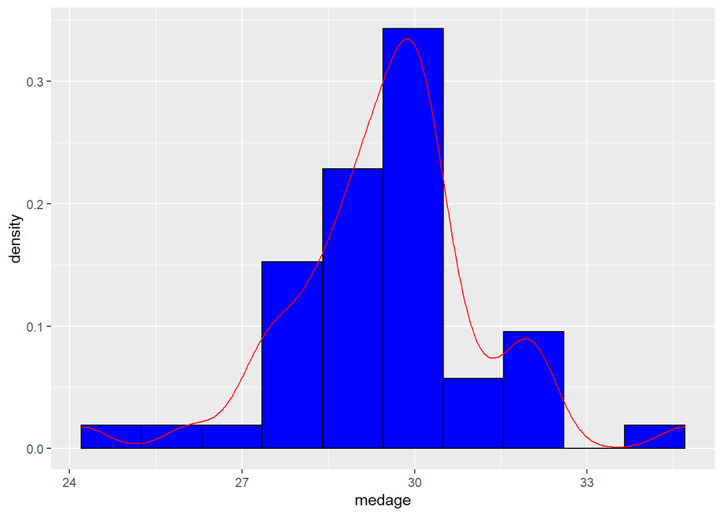

```r
# 5.6 Histograma "medage" y curva de densidad
vec = seq(min(census$medage), max(census$medage), length.out=11)
ggplot(data=census, aes(x=medage))+ geom_histogram(aes(y=stat(density)), breaks=vec, fill="blue", color="black")+ geom_density(color="red")
```

# Ejercicio 1. Análisis exploratorio de un conjunto de datos y operaciones con dplyr.

- Vamos a utilizar el conjunto de datos contenido en el fichero (es un enlace):  
  cholesterol.csv  
  Los datos proceden de un estudio realizado en la *University of Virginia School of Medicine* que investiga la prevalencia de la obesidad, la diabetes y otros factores de riesgo cardiovascular. Se puede encontrar más información sobre el fichero en este enlace:  
  https://biostat.app.vumc.org/wiki/pub/Main/DataSets/diabetes.html
- Carga el conjunto de datos en un data.frame de R llamado `chlstrl`.

```r
library(tidyverse)
library(dplyr)

chlstrl = read_csv("C:/Users/HP Omen/Documents/MASTER/Fundamentos Matemáticos/datos/cholesterol.csv")
```

- Empezaremos por información básica sobre el conjunto de datos. Cuántas observaciones contiene, cuáles son las variables y de qué tipos,… Información sobre los datos

```r
head(chlstrl)
```

```
## # A tibble: 6 x 7
##    chol   age gender height weight waist   hip
##   <dbl> <dbl> <chr>   <dbl>  <dbl> <dbl> <dbl>
## 1   203    46 female     62    121    29    38
## 2   165    29 female     64    218    46    48
## 3   228    58 female     61    256    49    57
## 4    78    67 male       67    119    33    38
## 5   249    64 male       68    183    44    41
## 6   248    34 male       71    190    36    42
```

```r
#número de filas
nrow(chlstrl)
```

```
## [1] 403
```

```r
#número de columnas
ncol(chlstrl)
```

```
## [1] 7
```

```r
#nombres de las variables
names(chlstrl)
```

```
## [1] "chol"   "age"    "gender" "height" "weight" "waist"  "hip"
```

```r
#clase de las variables
chlstrl %>%
  sapply(class)
```

```
##        chol         age      gender      height      weight       waist
##   "numeric"   "numeric" "character"   "numeric"   "numeric"   "numeric"
##         hip
##   "numeric"
```

- Asegúrate de comprobar si hay datos ausentes y localízalos en la tabla. NA’s

```r
colSums(is.na(chlstrl))
```

```
##   chol    age gender height weight  waist    hip
##      1      0      0      5      1      2      2
```

- El análisis exploratorio (numérico y gráfico) debe cubrir todos los tipos de variable de la tabla. Es decir, que al menos debes estudiar una variable por cada tipo de variable presente en la tabla. El análisis debe contener, al menos:
  - Para las variables cuantittativas (continuas o discretas).  
    Resumen numérico básico.  
    Gráficas (las adecuadas, a ser posible más de un tipo de gráfico).
  - Variables categóricas (factores).  
    Tablas de frecuencia (absolutas y relativas).  
    Gráficas (diagrama de barras).

Análisis Exploratorio de los datos

```r
summary(chlstrl)
```

```
##       chol            age           gender              height
##  Min.   : 78.0   Min.   :19.00   Length:403         Min.   :52.00
##  1st Qu.:179.0   1st Qu.:34.00   Class :character   1st Qu.:63.00
##  Median :204.0   Median :45.00   Mode  :character   Median :66.00
##  Mean   :207.8   Mean   :46.85                      Mean   :66.02
##  3rd Qu.:230.0   3rd Qu.:60.00                      3rd Qu.:69.00
##  Max.   :443.0   Max.   :92.00                      Max.   :76.00
##  NA's   :1                                          NA's   :5
##      weight          waist           hip
##  Min.   : 99.0   Min.   :26.0   Min.   :30.00
##  1st Qu.:151.0   1st Qu.:33.0   1st Qu.:39.00
##  Median :172.5   Median :37.0   Median :42.00
##  Mean   :177.6   Mean   :37.9   Mean   :43.04
##  3rd Qu.:200.0   3rd Qu.:41.0   3rd Qu.:46.00
##  Max.   :325.0   Max.   :56.0   Max.   :64.00
##  NA's   :1       NA's   :2      NA's   :2
```

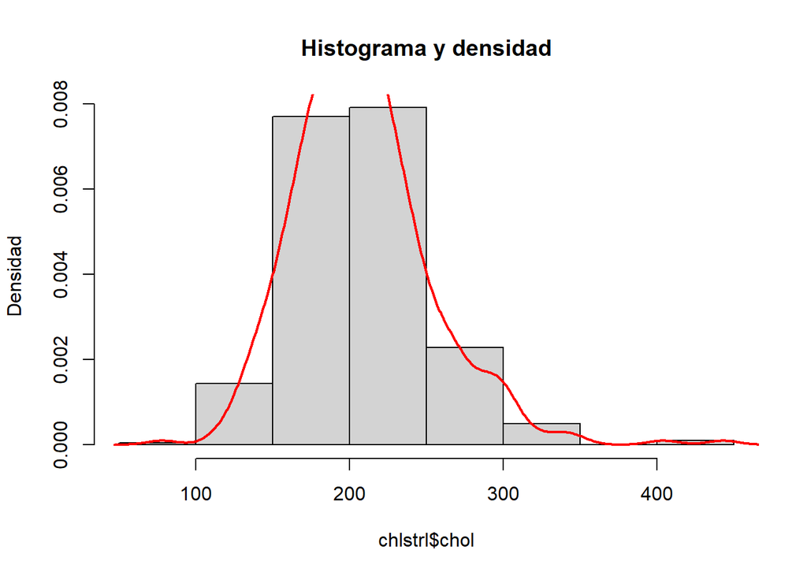

```r
#Variables Numéricas

hist(chlstrl$chol,freq = FALSE, main = "Histograma y densidad",
     ylab = "Densidad")
dx <- density(chlstrl$chol,na.rm = TRUE)
lines(dx, lwd = 2, col = "red")
```

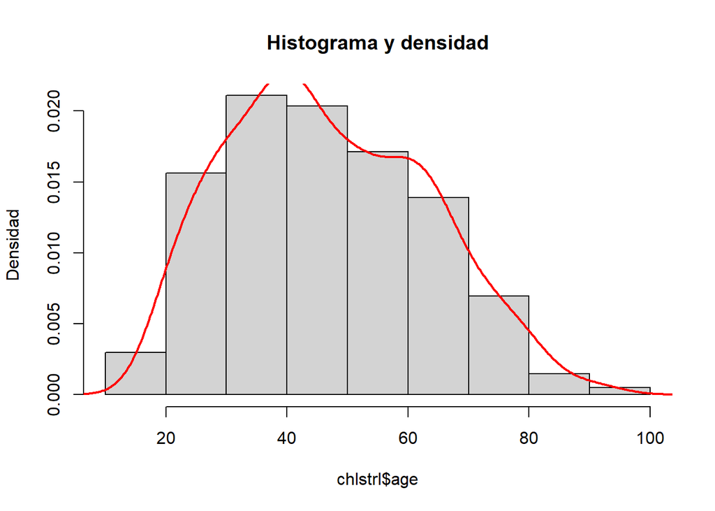

```r
hist(chlstrl$age,freq = FALSE, main = "Histograma y densidad",
     ylab = "Densidad")
dx <- density(chlstrl$age,na.rm = TRUE)
lines(dx, lwd = 2, col = "red")
```

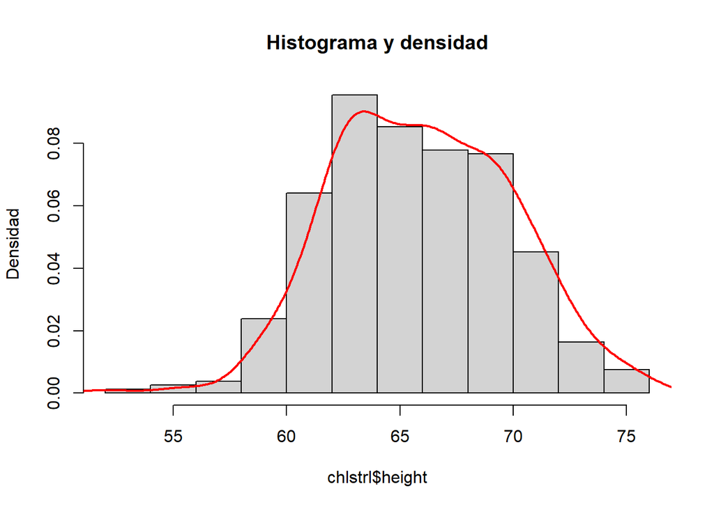

```r
hist(chlstrl$height,freq = FALSE, main = "Histograma y densidad",
     ylab = "Densidad")
dx <- density(chlstrl$height,na.rm = TRUE)
lines(dx, lwd = 2, col = "red")
```

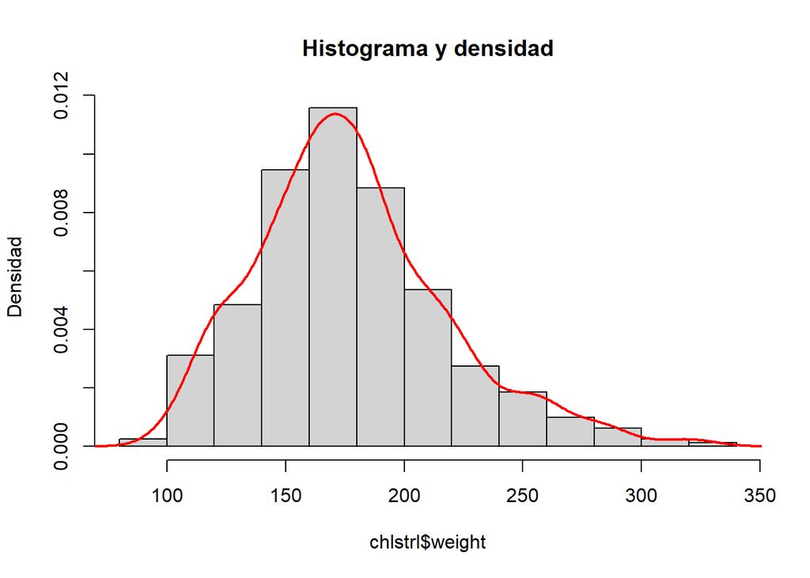

```r
hist(chlstrl$weight,freq = FALSE, main = "Histograma y densidad",
     ylab = "Densidad")
dx <- density(chlstrl$weight,na.rm = TRUE)
lines(dx, lwd = 2, col = "red")
```

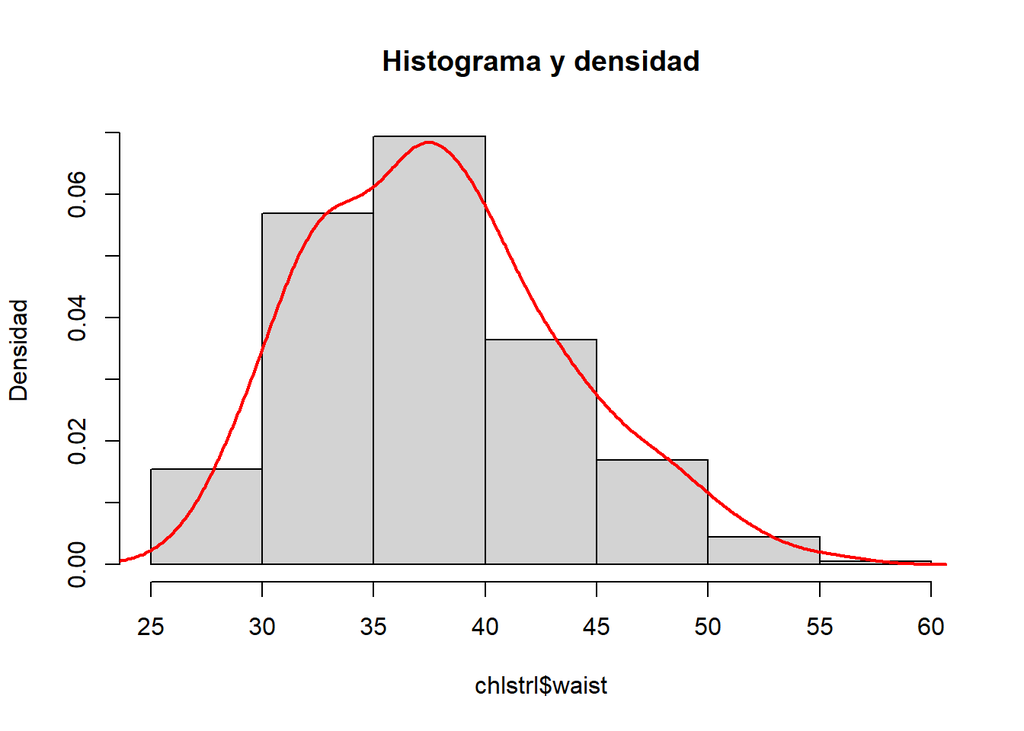

```r
hist(chlstrl$waist,freq = FALSE, main = "Histograma y densidad",
     ylab = "Densidad")
dx <- density(chlstrl$waist,na.rm = TRUE)
lines(dx, lwd = 2, col = "red")
```

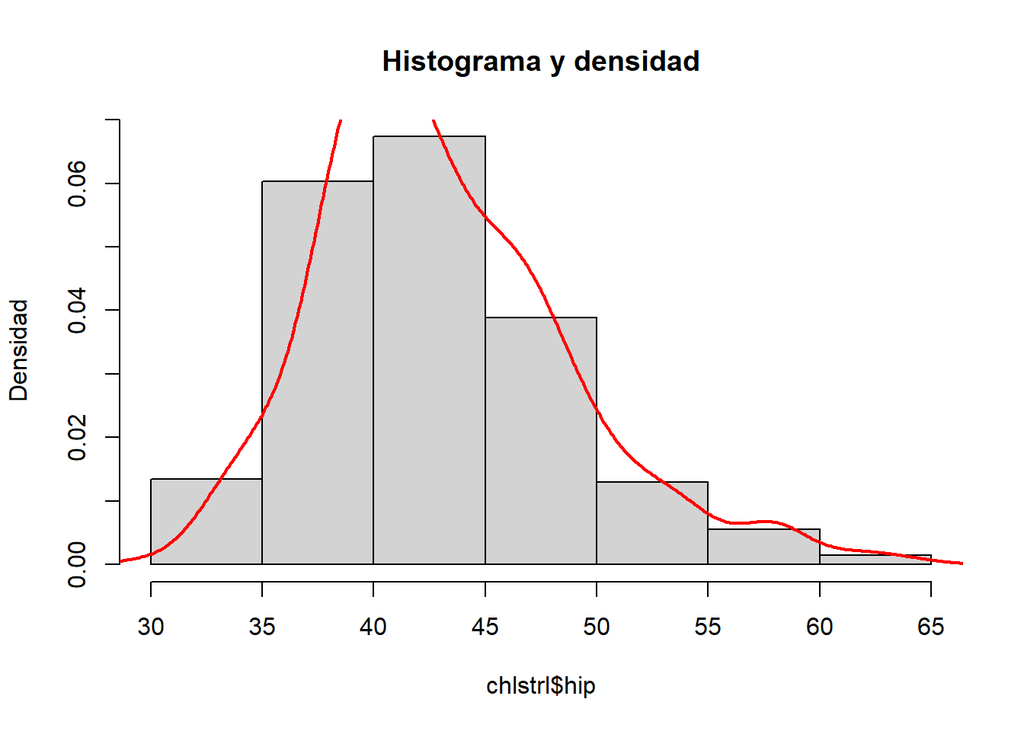

```r
hist(chlstrl$hip,freq = FALSE, main = "Histograma y densidad",
     ylab = "Densidad")
dx <- density(chlstrl$hip,na.rm = TRUE)
lines(dx, lwd = 2, col = "red")
```

```r
#Variables Categóricas


table(chlstrl$gender)
```

```
##
## female   male
##    234    169
```

```r
prop.table(table(chlstrl$gender))
```

```
##
##    female      male
## 0.5806452 0.4193548
```

```r
#medias de variables numéricas según género
chlstrl %>%
  group_by(gender) %>%
  summarise(meanChol = mean(chol, na.rm = TRUE),meanAge = mean(age, na.rm = TRUE), meanHeight = mean(height, na.rm = TRUE), meanWeight = mean(weight, na.rm = TRUE), meanWaist = mean(waist, na.rm = TRUE), meanHip = mean(hip, na.rm = TRUE))
```

```
## # A tibble: 2 x 7
##   gender meanChol meanAge meanHeight meanWeight meanWaist meanHip
##   <chr>     <dbl>   <dbl>      <dbl>      <dbl>     <dbl>   <dbl>
## 1 female     208.    45.8       63.7       174.      38.1    44.3
## 2 male       207.    48.3       69.1       182.      37.6    41.2
```

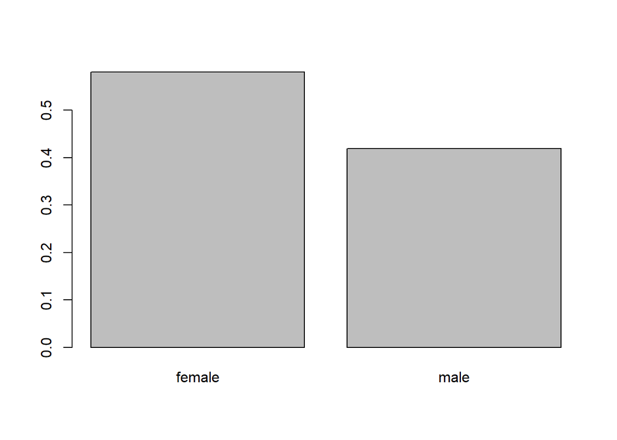

```r
barplot(prop.table(table(chlstrl$gender)))
```

- Los valores de `height` y `weight` están en pulgadas (inches) y libras (pounds) respectivamente. Una libra son $\approx$ 0.454kg y una pulgada son $\approx$ 0.0254m. Usa dplyr para convertir esas columnas a metros y kilogramos respectivamente. Las nuevas columnas deben llamarse igual que las originales.

```r
library(dplyr)
chlstrl0 = chlstrl %>%
  mutate(weight = weight * 0.454, height = height * 0.0254)
chlstrl0
```

```
## # A tibble: 403 x 7
##     chol   age gender height weight waist   hip
##    <dbl> <dbl> <chr>   <dbl>  <dbl> <dbl> <dbl>
##  1   203    46 female   1.57   54.9    29    38
##  2   165    29 female   1.63   99.0    46    48
##  3   228    58 female   1.55  116.     49    57
##  4    78    67 male     1.70   54.0    33    38
##  5   249    64 male     1.73   83.1    44    41
##  6   248    34 male     1.80   86.3    36    42
##  7   195    30 male     1.75   86.7    46    49
##  8   227    37 male     1.50   77.2    34    39
##  9   177    45 male     1.75   75.4    34    40
## 10   263    55 female   1.60   91.7    45    50
## # ... with 393 more rows
```

- Ahora usa esos valores de `height` y `weight` para añadir una nueva columna llamada BMI, definida mediante:
  $$BMI = \dfrac{weight}{height^2}$$
  (se divide por el cuadrado de la altura).

```r
chlstrl0 = chlstrl0 %>%
  mutate(BMI = weight/(height^2))
chlstrl0
```

```
## # A tibble: 403 x 8
##     chol   age gender height weight waist   hip   BMI
##    <dbl> <dbl> <chr>   <dbl>  <dbl> <dbl> <dbl> <dbl>
##  1   203    46 female   1.57   54.9    29    38  22.2
##  2   165    29 female   1.63   99.0    46    48  37.5
##  3   228    58 female   1.55  116.     49    57  48.4
##  4    78    67 male     1.70   54.0    33    38  18.7
##  5   249    64 male     1.73   83.1    44    41  27.8
##  6   248    34 male     1.80   86.3    36    42  26.5
##  7   195    30 male     1.75   86.7    46    49  28.2
##  8   227    37 male     1.50   77.2    34    39  34.4
##  9   177    45 male     1.75   75.4    34    40  24.5
## 10   263    55 female   1.60   91.7    45    50  35.8
## # ... with 393 more rows
```

- Crea una nueva columna llamada `ageGroup` dividiendo la edad en los siguientes tres niveles:

  ```
  (10,40], (40,70], (70,100]
  ```

```r
chlstrl0 = chlstrl0 %>%
  mutate(ageGroup = cut(age,breaks = c(10,40,70,100)))
chlstrl0
```

```
## # A tibble: 403 x 9
##     chol   age gender height weight waist   hip   BMI ageGroup
##    <dbl> <dbl> <chr>   <dbl>  <dbl> <dbl> <dbl> <dbl> <fct>
##  1   203    46 female   1.57   54.9    29    38  22.2 (40,70]
##  2   165    29 female   1.63   99.0    46    48  37.5 (10,40]
##  3   228    58 female   1.55  116.     49    57  48.4 (40,70]
##  4    78    67 male     1.70   54.0    33    38  18.7 (40,70]
##  5   249    64 male     1.73   83.1    44    41  27.8 (40,70]
##  6   248    34 male     1.80   86.3    36    42  26.5 (10,40]
##  7   195    30 male     1.75   86.7    46    49  28.2 (10,40]
##  8   227    37 male     1.50   77.2    34    39  34.4 (10,40]
##  9   177    45 male     1.75   75.4    34    40  24.5 (40,70]
## 10   263    55 female   1.60   91.7    45    50  35.8 (40,70]
## # ... with 393 more rows
```

- Usando `dplyr` calcula cuántas observaciones hay en cada nivel de `ageGroup` (indicación: usa `group_by`). Ahora, usando aquellas observaciones que corresponden a mujeres, ¿cuál es la media del nivel de colesterol y de BMI en cada uno de esos grupos de edad?

```r
chlstrl0 %>%
  group_by(ageGroup) %>%
  summarise(n = n())
```

```
## # A tibble: 3 x 2
##   ageGroup     n
##   <fct>    <int>
## 1 (10,40]    160
## 2 (40,70]    207
## 3 (70,100]    36
```

```r
chlstrl0 %>%
  filter(gender == "female") %>%
  group_by(ageGroup) %>%
  summarise(meanChol = mean(chol, na.rm = TRUE),
            meanBMI = mean(BMI, na.rm = TRUE))
```

```
## # A tibble: 3 x 3
##   ageGroup meanChol meanBMI
##   <fct>       <dbl>   <dbl>
## 1 (10,40]      189.    30.5
## 2 (40,70]      221.    30.3
## 3 (70,100]     230.    29.4
```

# Ejercicio 2: Funciones de R.

- Crea una función de R llamada `cambiosSigno` que dado un vector `x` de números enteros no nulos, como

  ```
  -12,  -19,  9,  -13,  -14,  -17,  8,  -19,  -14,
  ```

  calcule cuántos cambios de signo ha habido. Es decir, cuántas veces el signo de un elemento es distinto del signo del elemento previo. Por ejemplo, en el vector anterior hay 4 cambios de signo (en las posiciones 3, 4, 7 y 8).

```r
#ARREGLAR

y = c(-12,-19,9,-13,-14,-17,8,-19,-14)
u = c(1,-1,3)
cambiosSigno = function(x){
  difs = 0
  for(i in 1:(length(x)-1)){

    if(sign(x[i+1])!=sign(x[i])){
      difs = difs+1
    }
  }
  print(difs)
}
vec = sample(c(-100:1, 1:100), 20, replace = TRUE)
cambiosSigno(vec)
```

[output not shown]

- Modifica la función para que devuelva como resultado las posiciones donde hay cambios de signo. Llama `cambiosSignoPos(x)` a esa otra función. Por ejemplo, para el vector anterior el resultado de esta función sería [1] 3 4 7 8

```r
#METER SAMPLE

cambiosSignoPos = function(x){
  posiciones = c()
  difs = 0
  for(i in 1:(length(x)-1)){

    if(sign(x[i+1])!=sign(x[i])){
      difs = difs+1
      posiciones = c(posiciones,i+1)
    }
  }
  print(difs)
  print(posiciones)
}
cambiosSignoPos(y)
```

```
## [1] 4
## [1] 3 4 7 8
```

```
También se valorará que incluyas en el código como usar `sample` para generar vectores aleatorios de 20 enteros *no nulos* (el vector debe poder tomar valores positivos y negativos).
```